# Machine Learning Final Project

Didem Paloglu

2020-12-25

## Average Daily Rate of Hotel Bookings’ Prediction with Linear Regression

### 1. INTRODUCTION

Hotel bookings are very common in every day life. When we consider the factors that lead us to pay more for an hotel, we can analyze factors affecting the daily income of hotels.

The dataset contains different booking informations about two different hotel: City Hotel and Resort Hotel. Each observation represents a hotel booking. The dataset contains bookings due to arrive between the 1st of July of 2015 and the 31st of August 2017, including bookings that effectively arrived and bookings that were canceled. This is a real data set and it is avaliable at [Kaggle - Hotel Booking Demand Dataset](https://www.kaggle.com/jessemostipak/hotel-booking-demand).

In this project, the goal is the development of prediction models with regression of hotel booking’s average daily rate. It measures the average rental revenue earned for an occupied room per day. First, train and test samples was created and then train dataset was prepared for the linear regression. Prediction quality of the train data was compared on the test data. In final,the model accuracy tested with different methods.

#### 1.1. Exploring the Data

The dataset consists 119390 rows and 29 columns. There are both numerical and categorical variables in the dataset. The dependent variable is “adr” which is numerical. In the analysis,few rows having “0” ADR value were not included since it is not meaningful to analyze a zero rate. After removing observations that have 0 ADR value, total observations are 117431. All variables are listed as below:

| Variable Name | Variable Type | Description |
| --- | --- | --- |
| adr | Numeric | Average Daily Rate |
| adults | Integer | Number of adults |
| arrival_date_day_of_month | Integer | Day of the month of the arrival date |
| arrival_date_month | Categorical | Month of arrival date with 12 categories: “January” to “December” |
| arrival_date_week_number | Integer | Week number of the arrival date |
| arrival_date_year | Integer | Year of arrival date |
| assigned_room_type | Categorical | Code for the type of room assigned to the booking. Sometimes the assigned room type differs from the reserved room type due to hotel operation reasons (e.g.overbooking) or by customer request.Code is … |
| babies | Integer | Number of babies |
| booking_changes | Integer | Number of changes/amendments made to the booking from the moment the booking was entered on the PMS until the moment of check-in or cancellation |
| children | Integer | Number of children |
| customer_type | Categorical | Type of booking, assuming one of four categories: Contract - when the booking has an allotment or other type of contract associated to it; Group–when the booking is associated to a group; Transient–wh… |
| days_in_waiting_list | Integer | Number of days the booking was in the waiting list before it was confirmed to the customer |
| deposit_type | Categorical | Indication on if the customer made a deposit to guarantee the booking. This variable can assume three categories: No Deposit–no deposit was made; Non Refund–a deposit was made in the value of the tota… |
| distribution_channel | Categorical | Booking distribution channel. The term “TA” means “Travel Agents” and “TO” means “Tour Operators” |
| is_canceled | Categorical | Value indicating if the booking was canceled (1) or not (0) |
| is_repeated_guest | Categorical | Value indicating if the booking name was from a repeated guest (1) or not (0) |
| lead_time | Integer | Number of days that elapsed between the entering date of the booking into the PMS and the arrival date |
| market_segment | Categorical | Market segment designation. Incategories, the term “TA” means “TravelAgents” and “TO” means “TourOperators” |
| meal | Categorical | Type of meal booked. Categories are presented in standard hospitality mealpackages: Undefined/SC–no meal package; BB–Bed & Breakfast; HB–Half board (breakfast and one other meal–usually dinner); FB–Fu… |
| previous_bookings_not_canceled | Integer | Number of previous bookings not cancelled by the customer prior to the current booking |
| previous_cancellations | Integer | Number of previous bookings that were cancelled by the customer prior to the current booking |
| required_car_parking_spaces | Integer | Number of car parking spaces required by the customer |
| reservation_status | Categorical | Reservation last status, assuming one of three categories: Canceled–booking was canceled bythe customer; Check-Out–customer has checked inbut already departed; No-Show–customer did not check-in and di… |
| reservation_status_date | Date | Date at which the last status was set. This variable can be used in conjunction with the ReservationStatus to understand when was the booking canceled or when did the customer checked-out of the hotel |
| reserved_room_type | Categorical | Code of room type reserved. Code is presented instead of designation for anonymity reasons |
| stays_in_weekend_nights | Integer | Number of weekend nights (Saturday or Sunday) the guest stayed or booked to stay at the hotel |
| stays_in_week_nights | Integer | Number of week nights (Monday to Friday) the guest stayed or booked to stay at the hotel |
| total_of_special_requests | Integer | Number of special requests made by the customer (e.g. twin bed or highfloor) |

We can see the head of dataset as below:

Dataset Table with First 10 row

|  | hotel | is_canceled | lead_time | arrival_date_year | arrival_date_month | arrival_date_week_number | arrival_date_day_of_month | stays_in_weekend_nights | stays_in_week_nights | adults | children | babies | meal | market_segment | distribution_channel | is_repeated_guest | previous_cancellations | previous_bookings_not_canceled | reserved_room_type | assigned_room_type | booking_changes | deposit_type | days_in_waiting_list | customer_type | adr | required_car_parking_spaces | total_of_special_requests | reservation_status | reservation_status_date |
| --- | --- | --- | --- | --- | --- | --- | --- | --- | --- | --- | --- | --- | --- | --- | --- | --- | --- | --- | --- | --- | --- | --- | --- | --- | --- | --- | --- | --- | --- |
| 1 | City Hotel | 0 | 45 | 2016 | June | 27 | 27 | 1 | 3 | 3 | 0 | 0 | HB | Online TA | TA/TO | 0 | 0 | 0 | D | D | 0 | No Deposit | 0 | Transient | 157.68 | 0 | 2 | Check-Out | 1.07.2016 |
| 2 | City Hotel | 0 | 207 | 2017 | May | 18 | 5 | 1 | 2 | 2 | 0 | 0 | SC | Online TA | TA/TO | 0 | 0 | 0 | A | D | 0 | No Deposit | 0 | Transient | 99.00 | 0 | 1 | Check-Out | 8.05.2017 |
| 4 | Resort Hotel | 1 | 177 | 2017 | May | 21 | 25 | 1 | 3 | 2 | 2 | 0 | BB | Online TA | TA/TO | 0 | 0 | 0 | G | G | 0 | No Deposit | 0 | Transient | 155.00 | 0 | 1 | Canceled | 4.03.2017 |
| 5 | Resort Hotel | 1 | 19 | 2017 | July | 30 | 28 | 0 | 2 | 2 | 0 | 0 | BB | Online TA | TA/TO | 0 | 0 | 0 | A | A | 0 | No Deposit | 0 | Transient | 184.50 | 0 | 2 | No-Show | 28.07.2017 |
| 6 | Resort Hotel | 1 | 60 | 2017 | August | 34 | 20 | 4 | 7 | 2 | 0 | 0 | BB | Online TA | TA/TO | 0 | 0 | 0 | E | E | 0 | No Deposit | 0 | Transient | 255.45 | 0 | 3 | Canceled | 5.07.2017 |
| 7 | Resort Hotel | 1 | 60 | 2017 | August | 34 | 20 | 4 | 7 | 2 | 0 | 0 | BB | Online TA | TA/TO | 0 | 0 | 0 | E | E | 0 | No Deposit | 0 | Transient | 255.45 | 0 | 3 | Canceled | 5.07.2017 |
| 8 | Resort Hotel | 1 | 24 | 2017 | August | 34 | 23 | 2 | 4 | 2 | 0 | 0 | BB | Online TA | TA/TO | 0 | 0 | 0 | A | A | 0 | No Deposit | 0 | Transient | 216.67 | 0 | 1 | Canceled | 13.08.2017 |
| 9 | Resort Hotel | 0 | 3 | 2016 | May | 22 | 26 | 0 | 3 | 2 | 1 | 0 | BB | Online TA | TA/TO | 0 | 0 | 0 | H | H | 0 | No Deposit | 0 | Transient | 150.00 | 1 | 0 | Check-Out | 29.05.2016 |
| 10 | Resort Hotel | 0 | 0 | 2016 | June | 25 | 18 | 0 | 1 | 2 | 0 | 0 | BB | Direct | Direct | 0 | 0 | 0 | A | A | 1 | No Deposit | 0 | Transient | 112.50 | 0 | 0 | Check-Out | 19.06.2016 |
| 11 | Resort Hotel | 0 | 2 | 2016 | June | 26 | 25 | 1 | 1 | 1 | 0 | 0 | BB | Direct | Direct | 0 | 0 | 0 | C | C | 1 | No Deposit | 0 | Transient | 165.00 | 0 | 0 | Check-Out | 27.06.2016 |

#### 1.2. Insights About Data

Before starting the machine learning algorithms, let’s look at the data deeply and get some insights about variables. As can seen below, some variables such as is_canceled and is_repeated_guest should be converted to factor. After converting variables, the structure of the dataset looks like as below:

```
## Rows: 117,431
## Columns: 29
## $ hotel                          <fct> City Hotel, City Hotel, Resort Hotel...
## $ is_canceled                    <fct> 0, 0, 1, 1, 1, 1, 1, 0, 0, 0, 0, 0, ...
## $ lead_time                      <int> 45, 207, 177, 19, 60, 60, 24, 3, 0, ...
## $ arrival_date_year              <int> 2016, 2017, 2017, 2017, 2017, 2017, ...
## $ arrival_date_month             <fct> June, May, May, July, August, August...
## $ arrival_date_week_number       <int> 27, 18, 21, 30, 34, 34, 34, 22, 25, ...
## $ arrival_date_day_of_month      <int> 27, 5, 25, 28, 20, 20, 23, 26, 18, 2...
## $ stays_in_weekend_nights        <int> 1, 1, 1, 0, 4, 4, 2, 0, 0, 1, 0, 1, ...
## $ stays_in_week_nights           <int> 3, 2, 3, 2, 7, 7, 4, 3, 1, 1, 1, 4, ...
## $ adults                         <int> 3, 2, 2, 2, 2, 2, 2, 2, 2, 1, 2, 2, ...
## $ children                       <int> 0, 0, 2, 0, 0, 0, 0, 1, 0, 0, 2, 1, ...
## $ babies                         <int> 0, 0, 0, 0, 0, 0, 0, 0, 0, 0, 0, 0, ...
## $ meal                           <fct> HB, SC, BB, BB, BB, BB, BB, BB, BB, ...
```

[output cut: 16 more lines]

```
##           hotel       is_canceled   lead_time     arrival_date_year
##  City Hotel  :78122   0:73420     Min.   :  0.0   Min.   :2015
##  Resort Hotel:39309   1:44011     1st Qu.: 19.0   1st Qu.:2016
##                                   Median : 71.0   Median :2016
##                                   Mean   :105.1   Mean   :2016
##                                   3rd Qu.:162.0   3rd Qu.:2017
##                                   Max.   :709.0   Max.   :2017
##
##  arrival_date_month arrival_date_week_number arrival_date_day_of_month
##  August :13711      Min.   : 1.00            Min.   : 1.0
##  July   :12491      1st Qu.:16.00            1st Qu.: 8.0
##  May    :11611      Median :27.00            Median :16.0
##  April  :10953      Mean   :27.14            Mean   :15.8
##  October:10929      3rd Qu.:38.00            3rd Qu.:23.0
##  June   :10819      Max.   :53.00            Max.   :31.0
##  (Other):46917
##  stays_in_weekend_nights stays_in_week_nights     adults         children
##  Min.   : 0.0000         Min.   : 0.000       Min.   :0.000   Min.   : 0.0000
##  1st Qu.: 0.0000         1st Qu.: 1.000       1st Qu.:2.000   1st Qu.: 0.0000
##  Median : 1.0000         Median : 2.000       Median :2.000   Median : 0.0000
##  Mean   : 0.9364         Mean   : 2.521       Mean   :1.861   Mean   : 0.1045
##  3rd Qu.: 2.0000         3rd Qu.: 3.000       3rd Qu.:2.000   3rd Qu.: 0.0000
##  Max.   :19.0000         Max.   :50.000       Max.   :4.000   Max.   :10.0000
##
##      babies                 meal             market_segment
##  Min.   : 0.000000   BB       :90815   Aviation     :  231
##  1st Qu.: 0.000000   FB       :  782   Complementary:   63
##  Median : 0.000000   HB       :14262   Corporate    : 5213
##  Mean   : 0.007868   SC       :10441   Direct       :12368
##  3rd Qu.: 0.000000   Undefined: 1131   Groups       :19559
##  Max.   :10.000000                     Offline TA/TO:23887
##                                        Online TA    :56110
##  distribution_channel is_repeated_guest previous_cancellations
##  Corporate: 6485      0:114157          Min.   : 0.00000
##  Direct   :13839      1:  3274          1st Qu.: 0.00000
##  GDS      :  189                        Median : 0.00000
##  TA/TO    :96913                        Mean   : 0.08695
##  Undefined:    5                        3rd Qu.: 0.00000
##                                         Max.   :26.00000
##
```

[output cut: 17 more lines]

```
##  Contract       : 4052   Min.   :  0.26   Min.   :0.00000
##  Group          :  544   1st Qu.: 70.53   1st Qu.:0.00000
##  Transient      :88163   Median : 95.00   Median :0.00000
##  Transient-Party:24672   Mean   :103.49   Mean   :0.06264
##                          3rd Qu.:126.00   3rd Qu.:0.00000
##                          Max.   :540.00   Max.   :8.00000
##
##  total_of_special_requests reservation_status reservation_status_date
##  Min.   :0.000             Canceled :42830    Min.   :0001-01-20
##  1st Qu.:0.000             Check-Out:73420    1st Qu.:0008-06-20
##  Median :0.000             No-Show  : 1181    Median :0016-06-20
##  Mean   :0.571                                Mean   :0016-02-29
##  3rd Qu.:1.000                                3rd Qu.:0023-07-20
##  Max.   :5.000                                Max.   :0031-12-20
##
```

After examining the structure and summary findings about the data, we need to check if dataset consists any missing value. There is no missing values in the dataset.

```
##                          hotel                    is_canceled
##                              0                              0
##                      lead_time              arrival_date_year
##                              0                              0
##             arrival_date_month       arrival_date_week_number
##                              0                              0
##      arrival_date_day_of_month        stays_in_weekend_nights
##                              0                              0
##           stays_in_week_nights                         adults
##                              0                              0
##                       children                         babies
##                              0                              0
##                           meal                 market_segment
##                              0                              0
##           distribution_channel              is_repeated_guest
##                              0                              0
##         previous_cancellations previous_bookings_not_canceled
##                              0                              0
##             reserved_room_type             assigned_room_type
##                              0                              0
##                booking_changes                   deposit_type
##                              0                              0
##           days_in_waiting_list                  customer_type
##                              0                              0
##                            adr    required_car_parking_spaces
##                              0                              0
##      total_of_special_requests             reservation_status
##                              0                              0
##        reservation_status_date
##                              0
```

Let’s see some descriptive plots to understand dataset.

The left figure below shows the distribution of ADRs of bookings. According to the figure, average ADR of bookings is around $100 and there are some outliers which are greater than 500. The middle figure shows that the distribution of ADR is right skewed. Later, we will apply some transformation methods to obtain more normal distribution. Right figure shows that the room type H has the highest ADR, while the room type “L” has the lowest ADR.

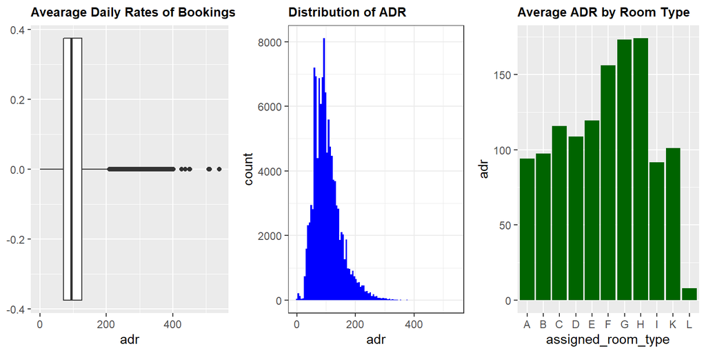

The left figure below shows the cancelazation frequencies by hotel type. It can be said that cancelazation of bookings is higher in city hotels than resort hotels. Moreover, total bookings are also higher than resort hotels. The right figure below shos the arrival time of guests to the hotels. It can be understood that most bookings were made in summer and people prefer to go to hotels mostly in August.

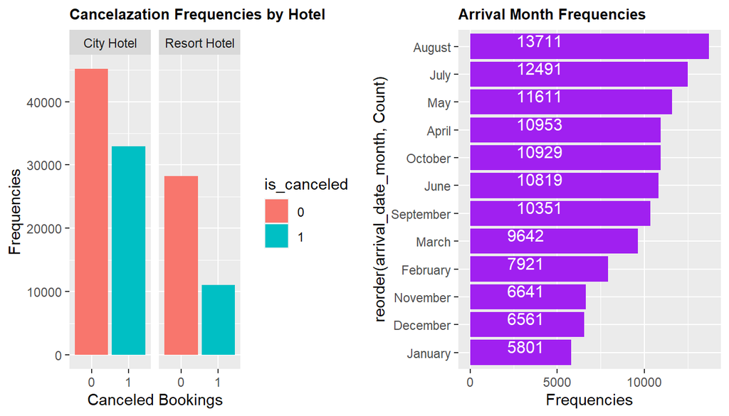

Another factor investigated is weekdays/weekend stay preferences. Most people book a room at most two weekends. In weekdays, people stay in hotels mostly for 0-10 days.

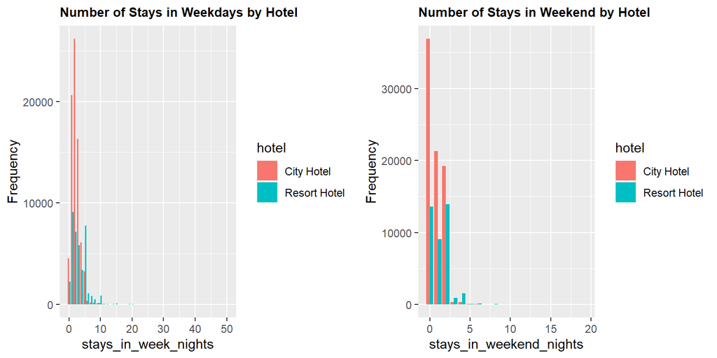

Last descriptive graph in below shows the rate of distribution channel of bookings. It can be said that 82.5% of bookings made by either travel agencies or tour operators followed by direct bookings with 11.8%.

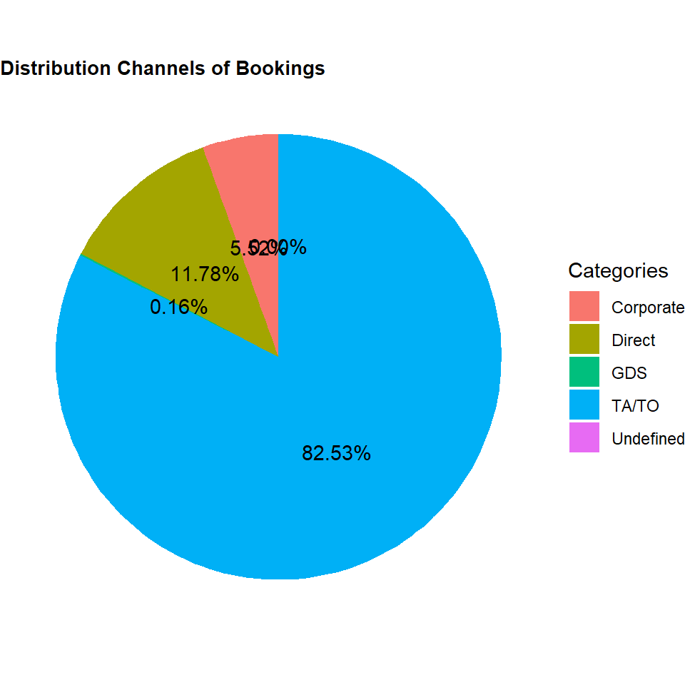

##### 1.3.1. Data Pre-Processing

After initial descriptive analysis, in order to start machine learning analysis, we need to split data into train and test datasets. For a random division `set.seed()` should be run before `createDataPartition()`. The data division was made as 70% for train sample and 30% for test sample. All variable selections and transformations will be based on the train dataset.

Below, dimensions of the train and test samples are provided. Train data contains 82203 observations and test data contains 35228 observations.

```r
dim(booking_train)
```

```
## [1] 82203    29
```

```r
dim(booking_test)
```

```
## [1] 35228    29
```

We can pre-select variables for the model to check the relation of each of them separately with the outcome variable. We can show relation of variables with target variable for both numerical variables and categorical variables. Correlation analysis is helpful to see the relationship of numerical independent variables with target variable and also helpful to detect if there is any collinearity among variables. ANOVA analysis is helpful to see the relation of the target variable with the categorical variables that most strongly associated with it.

Below is the correlation plot of numerical variables. The strongest relation is between arrival_date_week_number and arrival_date_year. But, this correlation does not imply a collinearity.

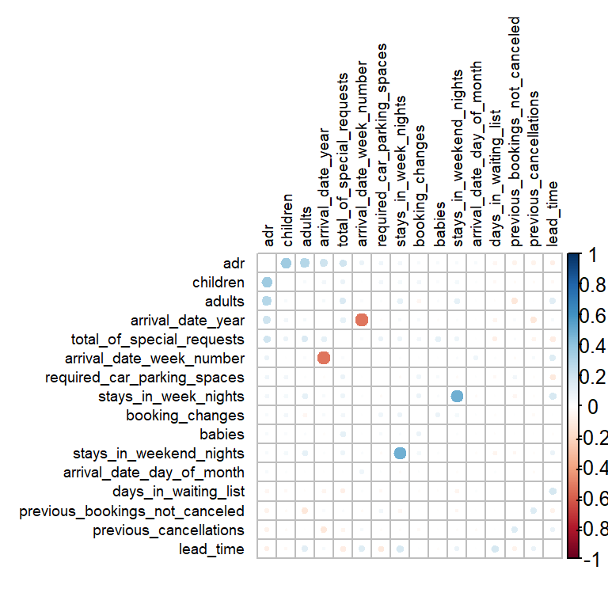

After we looked at the relations between numerical independent variables and outcome variable, we looked also the relations between categorical independent variables and outcome variable. Below gives F-statistics of the ANOVA test. *reserved_room_type variable* is highest associated with outcome and *reservation_status* variable is least associated variable with the target variable.

```
##   reserved_room_type       market_segment   arrival_date_month
##           2806.65977           2253.63593           2191.52911
##   assigned_room_type        customer_type    is_repeated_guest
##           1311.14165           1065.08396            892.08101
##                hotel distribution_channel         deposit_type
##            876.77270            688.15859            540.02826
##                 meal          is_canceled   reservation_status
##            466.12451             86.43109             48.24176
```

Other issue is to check if a variable is linear combination of some other variables. When we test the linear combination of the variables, we can say that there is no linear combination in the dataset.

```
## $linearCombos
## list()
##
## $remove
## NULL
```

Last thing to check about variables is near zero variance. If dataset has any variable with zero variance (it means that observations do not vary in variable), then it should be removed from the analysis. The result gives **TRUE** for days_in_waiting_list, babies, previous_bookings_not_canceled, is_repeated_guest and children. This implies that these variables will not be included in the linear regression.

```
##                           zmienna  freqRatio percentUnique zeroVar   nzv
## 1            days_in_waiting_list 491.518519   0.147196574   FALSE  TRUE
## 2                          babies 132.426948   0.004866002   FALSE  TRUE
## 3  previous_bookings_not_canceled  77.515534   0.070557036   FALSE  TRUE
## 4               is_repeated_guest  34.912189   0.002433001   FALSE  TRUE
## 5                        children  22.627300   0.006082503   FALSE  TRUE
## 6          previous_cancellations  18.536481   0.018247509   FALSE FALSE
## 7     required_car_parking_spaces  15.302718   0.006082503   FALSE FALSE
## 8                 booking_changes   8.190175   0.021897011   FALSE FALSE
## 9                    deposit_type   7.065245   0.003649502   FALSE FALSE
## 10           distribution_channel   6.999794   0.006082503   FALSE FALSE
## 11                           meal   6.336757   0.006082503   FALSE FALSE
## 12             reserved_room_type   4.432738   0.010948506   FALSE FALSE
## 13                         adults   3.998583   0.006082503   FALSE FALSE
## 14                  customer_type   3.591546   0.004866002   FALSE FALSE
## 15             assigned_room_type   2.925412   0.013381507   FALSE FALSE
## 16                 market_segment   2.350409   0.008515504   FALSE FALSE
## 17      total_of_special_requests   2.103316   0.007299004   FALSE FALSE
## 18                          hotel   1.979665   0.002433001   FALSE FALSE
## 19                      lead_time   1.772528   0.577837792   FALSE FALSE
## 20             reservation_status   1.712343   0.003649502   FALSE FALSE
## 21                    is_canceled   1.666245   0.002433001   FALSE FALSE
## 22        stays_in_weekend_nights   1.513673   0.017031009   FALSE FALSE
## 23        reservation_status_date   1.482278   0.445239225   FALSE FALSE
## 24                            adr   1.384411   9.126187609   FALSE FALSE
## 25              arrival_date_year   1.382750   0.003649502   FALSE FALSE
## 26       arrival_date_week_number   1.170253   0.064474533   FALSE FALSE
## 27           stays_in_week_nights   1.128172   0.036495018   FALSE FALSE
## 28             arrival_date_month   1.105281   0.014598007   FALSE FALSE
## 29      arrival_date_day_of_month   1.018176   0.037711519   FALSE FALSE
```

After removing zero variance variables, we have below variables to use as regressors in the train dataset for the linear regression:

```
##  [1] "hotel"                       "is_canceled"
##  [3] "lead_time"                   "arrival_date_year"
##  [5] "arrival_date_month"          "arrival_date_week_number"
##  [7] "arrival_date_day_of_month"   "stays_in_weekend_nights"
##  [9] "stays_in_week_nights"        "adults"
## [11] "meal"                        "market_segment"
## [13] "distribution_channel"        "previous_cancellations"
## [15] "reserved_room_type"          "assigned_room_type"
## [17] "booking_changes"             "deposit_type"
## [19] "customer_type"               "adr"
## [21] "required_car_parking_spaces" "total_of_special_requests"
## [23] "reservation_status"          "reservation_status_date"
```

All variables are prepared for machine learning processes and the following section gives how linear regression is applied for prediction of average daily rate of hotel bookings.

### 2. METHODOLOGY

For obtaining a good model with high prediction accuracy, first step is constructing a reference model. This model will be compared with different models during the analysis and best model will be determined. Reference model constructed with two set of variables. In the first reference model, all variables selected in the previous section were used. The result gived a coefficient with NAs which is “reservation_status”. So, second model did not include this variable.

```r
# model with all variables

booking_lm1 <- lm(adr ~ .,
                 data = booking_train)
```

```
##
## Call:
## lm(formula = adr ~ ., data = booking_train)
##
## Residuals:
##     Min      1Q  Median      3Q     Max
## -208.66  -17.95   -2.24   14.20  455.01
##
## Coefficients: (1 not defined because of singularities)
##                                  Estimate Std. Error t value Pr(>|t|)
## (Intercept)                    -3.371e+04  4.359e+02 -77.325  < 2e-16 ***
## hotelResort Hotel              -2.490e+01  2.625e-01 -94.856  < 2e-16 ***
## is_canceled1                    4.429e+00  2.621e-01  16.897  < 2e-16 ***
## lead_time                      -1.056e-01  1.217e-03 -86.773  < 2e-16 ***
## arrival_date_year               1.675e+01  2.148e-01  77.962  < 2e-16 ***
## arrival_date_monthAugust        5.201e+01  4.530e+00  11.481  < 2e-16 ***
## arrival_date_monthDecember      1.420e+01  9.048e+00   1.569 0.116668
## arrival_date_monthFebruary     -2.984e+01  2.266e+00 -13.169  < 2e-16 ***
## arrival_date_monthJanuary      -3.566e+01  3.411e+00 -10.454  < 2e-16 ***
## arrival_date_monthJuly          3.880e+01  3.384e+00  11.466  < 2e-16 ***
## arrival_date_monthJune          2.461e+01  2.312e+00  10.645  < 2e-16 ***
## arrival_date_monthMarch        -1.987e+01  1.245e+00 -15.966  < 2e-16 ***
## arrival_date_monthMay           1.546e+01  1.212e+00  12.753  < 2e-16 ***
## arrival_date_monthNovember      1.052e+01  7.966e+00   1.320 0.186780
## arrival_date_monthOctober       2.506e+01  6.800e+00   3.686 0.000228 ***
## arrival_date_monthSeptember     3.994e+01  5.684e+00   7.026 2.14e-12 ***
## arrival_date_week_number       -4.538e-01  2.597e-01  -1.747 0.080609 .
## arrival_date_day_of_month       2.086e-01  3.916e-02   5.326 1.01e-07 ***
## stays_in_weekend_nights        -1.331e+00  1.184e-01 -11.240  < 2e-16 ***
## stays_in_week_nights            4.953e-01  6.435e-02   7.697 1.41e-14 ***
## adults                          9.825e+00  2.373e-01  41.398  < 2e-16 ***
## children                        1.229e+01  3.377e-01  36.405  < 2e-16 ***
## babies                          6.459e-01  1.058e+00   0.610 0.541677
## mealFB                          4.589e+01  1.259e+00  36.447  < 2e-16 ***
## mealHB                          2.742e+01  3.289e-01  83.351  < 2e-16 ***
## mealSC                         -1.478e+01  3.957e-01 -37.338  < 2e-16 ***
## mealUndefined                   4.179e+01  1.079e+00  38.711  < 2e-16 ***
## market_segmentComplementary    -6.195e+01  4.878e+00 -12.699  < 2e-16 ***
## market_segmentCorporate        -5.100e+00  2.326e+00  -2.192 0.028349 *
## market_segmentDirect            9.286e+00  2.504e+00   3.708 0.000209 ***
```

[output cut: 31 more lines]

```
## days_in_waiting_list            6.689e-02  5.862e-03  11.412  < 2e-16 ***
## customer_typeGroup             -2.951e-01  1.568e+00  -0.188 0.850752
## customer_typeTransient          3.678e+00  5.842e-01   6.296 3.07e-10 ***
## customer_typeTransient-Party    6.304e+00  6.148e-01  10.254  < 2e-16 ***
## required_car_parking_spaces     5.974e+00  4.363e-01  13.693  < 2e-16 ***
## total_of_special_requests       2.055e+00  1.474e-01  13.941  < 2e-16 ***
## reservation_statusCheck-Out            NA         NA      NA       NA
## reservation_statusNo-Show      -1.071e+00  1.022e+00  -1.047 0.294883
## reservation_status_date        -1.599e-05  3.290e-05  -0.486 0.626966
## ---
## Signif. codes:  0 '***' 0.001 '**' 0.01 '*' 0.05 '.' 0.1 ' ' 1
##
## Residual standard error: 28.66 on 82134 degrees of freedom
## Multiple R-squared:  0.6248, Adjusted R-squared:  0.6245
## F-statistic:  2012 on 68 and 82134 DF,  p-value: < 2.2e-16
```

```r
# model with selected variables

booking_lm2 <- lm(adr ~ .,
                  data = booking_train %>%
                    dplyr::select(all_of(booking_variables_selected)))
```

```
##
## Call:
## lm(formula = adr ~ ., data = booking_train %>% dplyr::select(all_of(booking_variables_selected)))
##
## Residuals:
##     Min      1Q  Median      3Q     Max
## -198.90  -18.01   -2.16   14.54  454.71
##
## Coefficients:
##                                 Estimate Std. Error t value Pr(>|t|)
## (Intercept)                   -3.379e+04  4.393e+02 -76.917  < 2e-16 ***
## hotelResort Hotel             -2.617e+01  2.626e-01 -99.662  < 2e-16 ***
## is_canceled1                   4.758e+00  2.600e-01  18.300  < 2e-16 ***
## lead_time                     -1.031e-01  1.219e-03 -84.601  < 2e-16 ***
## arrival_date_year              1.679e+01  2.165e-01  77.550  < 2e-16 ***
## arrival_date_monthAugust       4.981e+01  4.566e+00  10.911  < 2e-16 ***
## arrival_date_monthDecember     8.736e+00  9.121e+00   0.958 0.338172
## arrival_date_monthFebruary    -2.858e+01  2.284e+00 -12.512  < 2e-16 ***
## arrival_date_monthJanuary     -3.394e+01  3.438e+00  -9.873  < 2e-16 ***
## arrival_date_monthJuly         3.706e+01  3.410e+00  10.867  < 2e-16 ***
## arrival_date_monthJune         2.288e+01  2.330e+00   9.820  < 2e-16 ***
## arrival_date_monthMarch       -1.958e+01  1.255e+00 -15.599  < 2e-16 ***
## arrival_date_monthMay          1.446e+01  1.222e+00  11.830  < 2e-16 ***
## arrival_date_monthNovember     5.360e+00  8.029e+00   0.668 0.504361
## arrival_date_monthOctober      2.085e+01  6.854e+00   3.043 0.002347 **
## arrival_date_monthSeptember    3.619e+01  5.729e+00   6.317 2.67e-10 ***
## arrival_date_week_number      -2.992e-01  2.618e-01  -1.143 0.253018
## arrival_date_day_of_month      1.917e-01  3.949e-02   4.855 1.21e-06 ***
## stays_in_weekend_nights       -1.344e+00  1.193e-01 -11.264  < 2e-16 ***
## stays_in_week_nights           5.464e-01  6.494e-02   8.415  < 2e-16 ***
## adults                         9.190e+00  2.374e-01  38.715  < 2e-16 ***
## mealFB                         4.713e+01  1.271e+00  37.090  < 2e-16 ***
## mealHB                         2.783e+01  3.319e-01  83.849  < 2e-16 ***
## mealSC                        -1.587e+01  3.983e-01 -39.847  < 2e-16 ***
## mealUndefined                  4.271e+01  1.090e+00  39.197  < 2e-16 ***
## market_segmentComplementary   -5.967e+01  4.925e+00 -12.117  < 2e-16 ***
## market_segmentCorporate       -5.505e+00  2.345e+00  -2.348 0.018891 *
## market_segmentDirect           1.045e+01  2.527e+00   4.135 3.55e-05 ***
## market_segmentGroups          -7.566e+00  2.437e+00  -3.105 0.001907 **
## market_segmentOffline TA/TO   -3.562e+00  2.436e+00  -1.463 0.143600
```

[output cut: 24 more lines]

```
## booking_changes                1.525e+00  1.674e-01   9.112  < 2e-16 ***
## deposit_typeNon Refund         1.630e+01  4.774e-01  34.150  < 2e-16 ***
## deposit_typeRefundable         1.763e+01  2.666e+00   6.614 3.77e-11 ***
## customer_typeGroup            -2.032e+00  1.576e+00  -1.290 0.197208
## customer_typeTransient         3.799e+00  5.897e-01   6.443 1.18e-10 ***
## customer_typeTransient-Party   6.439e+00  6.194e-01  10.395  < 2e-16 ***
## required_car_parking_spaces    5.662e+00  4.400e-01  12.868  < 2e-16 ***
## total_of_special_requests      2.124e+00  1.476e-01  14.393  < 2e-16 ***
## reservation_status_date       -9.960e-06  3.321e-05  -0.300 0.764225
## ---
## Signif. codes:  0 '***' 0.001 '**' 0.01 '*' 0.05 '.' 0.1 ' ' 1
##
## Residual standard error: 28.94 on 82140 degrees of freedom
## Multiple R-squared:  0.6174, Adjusted R-squared:  0.6171
## F-statistic:  2137 on 62 and 82140 DF,  p-value: < 2.2e-16
```

According to results of reference models in above, first model is more powerful since it has higher R2 (0.6245). Second model (without NAs) was taken as reference model. Now, feature selection and feature transformation techniques will be applied on the train data.

#### 2.2. Feature Transformation

Since we have continuous dependent variable, we will check the distribution of it. It is clearly right skewed as can seen from the left figure below. When we take logaritm of it, its shape is more close to normal. We will try to apply log transformation to see how models’ accuracy change.

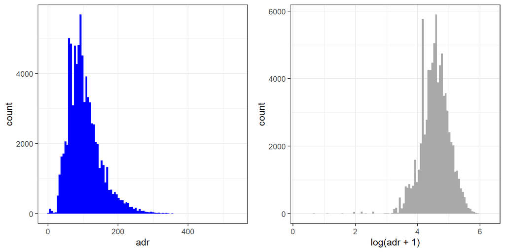

Next step is constructing the model with log transformation for dependent variable (log(adr + 1)), and then all models constructed will be compared. The models were constructed with 5 folds cross validation. In below, all models is provided and results of accuracies will be given following steps.

```r
ctrl_cv5 <- trainControl(method = "cv",
                         number = 5)

# model with all variables
set.seed(987654321)

booking_lm0_all <- train(adr ~ .,
                         data = booking_train,
                         method  = "lm",
                         trControl = ctrl_cv5)

# model with selected variables
set.seed(987654321)
booking_lm0_selected <- train(adr ~ .,
                              data = booking_train %>%
                              dplyr::select(all_of(booking_variables_selected)),
                              method  = "lm",
                              trControl = ctrl_cv5)


# model with all variables and log transformation in target variable adr
set.seed(987654321)
booking_lm1_all_log <- train(log(adr + 1) ~ .,
                             data = booking_train,
                             method  = "lm",
                             trControl = ctrl_cv5)

# model with selected variables and log transformation in target variable adr
set.seed(987654321)

booking_lm1_selected_log <- train(log(adr + 1) ~ .,
                                  data = booking_train %>%
                                  dplyr::select(all_of(booking_variables_selected)),
                                  method  = "lm",
                                  trControl = ctrl_cv5)
```

Regression Metrics of Fitted Prediction on Train Data

|  | MSE | RMSE | MAE | MedAE | MSLE | R2 |
| --- | --- | --- | --- | --- | --- | --- |
| booking_lm0_all | 820.501958197552 | 28.6444053559775 | 21.1071594819435 | 16.3518972192897 | NaN | 0.624830489337005 |
| booking_lm0_selected | 836.861804578705 | 28.9285638181142 | 21.3067010709975 | 16.4847867329212 | NaN | 0.617350049467219 |
| booking_lm1_all_log | 858.598165644025 | 29.301845771965 | 20.4599650342543 | 14.5720081960941 | 0.0812237551646057 | 0.607411231085378 |
| booking_lm1_selected_log | 868.278862022521 | 29.4665719421605 | 20.5860289530433 | 14.557251901039 | 0.0820205187377598 | 0.60298479177355 |

Regression Metrics of Forecasts on Test Data

|  | MSE | RMSE | MAE | MedAE | MSLE | R2 |
| --- | --- | --- | --- | --- | --- | --- |
| booking_lm0_all | 831.47008793983 | 28.8352230430047 | 21.3070280240597 | 16.4513578905261 | NaN | 0.617642003020846 |
| booking_lm0_selected | 850.376346418073 | 29.161213047781 | 21.5219897672938 | 16.6259046178557 | NaN | 0.608947812782418 |
| booking_lm1_all_log | 864.004824740684 | 29.3939589837892 | 20.5718930484993 | 14.598252653155 | 0.0846770228897467 | 0.602680650861755 |
| booking_lm1_selected_log | 876.696233991545 | 29.6090566211007 | 20.7259707648657 | 14.5916994901977 | 0.0856134645380038 | 0.596844407453377 |

When we take the logarithm of the response variable, R2 decreased a little. In the log transformed models (all variables vs selected variables), there is too little difference in R2s and taking logarithm caused a decrease in R2.

Second table above shows the forecast values on the test dataset. The prediction errors on the test data is similar to prediciton in the train data. MSE increased a little for the prediction on the test data.

After trying different linear models, now we will try to compare our models with other methods. The following section shows different machine learning methods for comparison with linear regression.

#### 2.3. Model Comparison

###### 2.3.1. KNN

R codes of this method is provided in the RMarkdown file. However, this code takes too long time to compute the model.

```r
## knn
# options(contrasts = c("contr.treatment",  # for non-ordinal factors
#                       "contr.treatment")) # for ordinal factors
#
# sqrt(nrow(booking_train))
#
# k_value <- data.frame(k = 287)
#
# set.seed(987654321)
#
# booking_lm_knn <-train(log(adr + 1) ~.,
#                         data = booking_train %>%
#                         dplyr::select(all_of(booking_variables_selected)),
#                         method  = "knn",
#                         trControl = ctrl_cv5)
#
# booking_lm_knn_fitted <- predict(booking_lm_knn,
#                                    booking_train)
#
# booking_lm_knn_fitted <- exp(booking_lm_knn_fitted) -1
#
#
# booking_lm_knn_forecast <- predict(booking_lm_knn,
#                                  booking_test)
#
# booking_lm_knn_forecast <- exp(booking_lm_knn_forecast) -1
#
#
# regressionMetrics(booking_train$adr, booking_lm_knn_fitted )
# regressionMetrics(booking_test$adr, booking_lm_knn_forecast )
```

###### 2.3.2. SVM

R codes of this method is provided in the RMarkdown file. However, this code takes too long time to compute the model.

```r
# # linear
#
# options(contrasts = c("contr.treatment",  # for non-ordinal factors
#                       "contr.treatment")) # for ordinal factors
#
# # parametersC <- data.frame(C = c(0.001, 0.01, 0.02, 0.05,
# #                                 0.1, 0.2, 0.5, 1, 2, 5))
#
# set.seed(987654321)
#
# booking.svm_Linear <- train(adr ~ .,
#                             data = booking_train %>%
#                               dplyr::select(all_of(booking_variables_selected)),
#                            method = "svmLinear",
#                            # tuneGrid = parametersC,
#                            trControl = ctrl_cv5)
#
# booking.svm_Linear
#
# ## poly
#
# svm_parametersPoly <- expand.grid(C = c(0.001, 1),
#                                   degree = 2:5,
#                                   scale = 1)
#
# svm_parametersPoly
#
# set.seed(987654321)
#
# booking.svm_poly <- train(adr ~ .,
#                         data = booking_train %>%
#                           dplyr::select(all_of(booking_variables_selected)),
#                         method = "svmPoly",
#                         # tuneGrid = svm_parametersPoly,
#                         trControl = ctrl_cv5)
#
# booking.svm_poly
#
# # radial
#
# parametersC_sigma <-
#   expand.grid(C = c(0.01, 0.05, 0.1, 0.5, 1, 5),
#               sigma = c(0.05, 0.1, 0.2, 0.5, 1))
#
# set.seed(987654321)
#
# booking.svm_Radial <- train(adr ~ .,
#                             data = booking_train %>%
#                               dplyr::select(all_of(booking_variables_selected)),
#                            method = "svmRadial",
#                            tuneGrid = parametersC_sigma,
#                            trControl = ctrl_cv5)
#
# plot(booking.svm_Radial$finalModel)
#
# booking.svm_Radial_forecast <- predict(booking.svm_Radial,
#                                        data2_test)
#
#
# regressionMetrics(booking_test$adr, booking.svm_Radial_forecast)
#
#
#
# data2.svm_Radial1
```

###### 2.3.3. Ridge-LASSO

The model was constructed with mixed method that gives the optimal result between Ridge and LASSO methods.

```r
# mixed method

# parameters_elastic <- expand.grid(alpha = seq(0, 1, 0.2),
#                                  lambda = seq(10, 1e4, 10))
# set.seed(987654321)
#
# booking_elastic <- train(adr ~ .,
#                        data = booking_train %>%
#                        dplyr::select(all_of(booking_variables_selected)),
#                        method = "glmnet",
#                        tuneGrid = parameters_elastic,
#                        trControl = ctrl_cv5)
#
# head(booking_elastic, 10)
#
# elastic_fitted <- predict(booking_elastic, booking_train)
#
# elastic_forecast <- predict(booking_elastic, booking_test)
#
#
#
# s1 <- sapply(elastic_fitted,
#        function(x) regressionMetrics(
#                                      booking_train$adr, x)) %>%
#   t()
#
# s2 <- sapply(elastic_forecast,
#        function(x) regressionMetrics(
#                                      booking_test$adr, x)) %>%
#   t()
#
# kable(s1, caption = "Regression Metrics of Fitted Prediction of Mixed Ridge-LASSO") %>%
#    kable_styling(font_size = 10, bootstrap_options = "bordered")
#
# kable(s2, caption = "Regression Metrics of Forecasts on Mixed Ridge-LASSO") %>%
#    kable_styling(font_size = 10, bootstrap_options = "bordered")
#
```